# Лабораторная работа № 7

Дискретно-событийное моделирование

Куокконен Дарина Андреевна

Российский университет дружбы народов имени Патриса Лумумбы

НФИбд-01-23

2026-08-31

# Вводная часть

## Цель и задачи

**Цель:** исследовать ожидание обслуживания и надёжность систем с ограниченными ресурсами.

- реализовать M/M/c и систему ремонта Росса;
- сохранить параметры исходных примеров;
- изменить интенсивности, число каналов, машин и ремонтников;
- измерить очереди и загрузку по времени;
- сопоставить опыты с аналитикой и выполнить четыре блокнота.

## События вместо фиксированного шага

- `Simulation` хранит календарь ближайших событий.
- `@process` создаёт процесс, `@yield` приостанавливает его.
- `Resource` ограничивает число обслуживаемых одновременно.
- `Store{Process}` хранит резервные машины.
- Между событиями состояние постоянно: средние считаются интегралами.

ConcurrentSim 1.5.1 · ResumableFunctions 1.0.7 · Julia 1.11.9.

## M/M/c: условие устойчивости

$$\rho=\frac{\lambda}{c\mu}<1,\qquad
W_q=\frac{P_{wait}}{c\mu-\lambda},\qquad W=W_q+\frac1\mu.$$

- Общая неограниченная FIFO-очередь; c одинаковых каналов.
- Межприходное время: `Exponential(1/λ)`.
- Обслуживание: `Exponential(1/μ)`.
- При ρ≥1 стационарного среднего ожидания нет.

# Очередь M/M/c

## Базовый опыт: десять клиентов

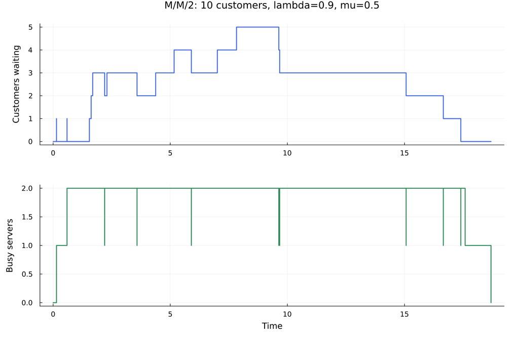

- c=2; λ=0,9; μ=0,5.
- seed=123.
- Wq=4,856796.
- Последний уход: 18,690265.
- Все 10 обслужены.

## Ожидание и обслуживание различаются

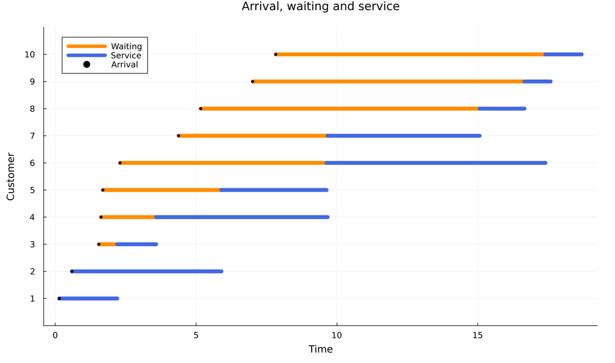

Оранжевый участок — ожидание; синий — обслуживание; точка — прибытие.

FIFO упорядочивает начала, но не окончания обслуживания.

## Длинная серия и Эрланг C

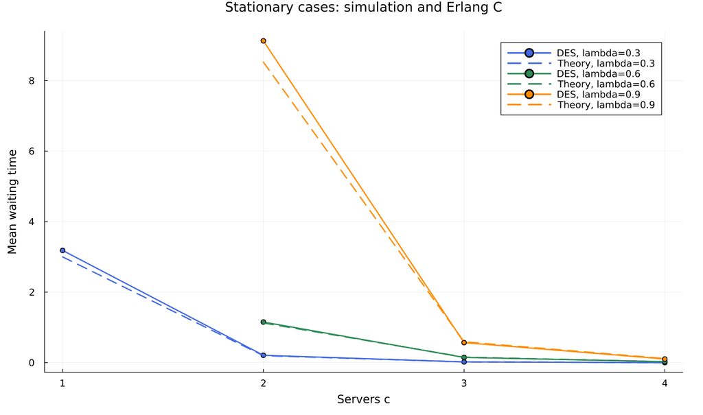

λ={0,3;0,6;0,9}; c={1;2;3;4}; μ=0,5.

12 × 20 000 клиентов; первые 2 000 исключены из оценок.

## Добавление канала сокращает ожидание

| λ=0,9 | c=2 | c=3 | c=4 |
| --- | --- | --- | --- |
| Загрузка ρ | 0,90 | 0,60 | 0,45 |
| Wq, опыт | 9,128937 | 0,567654 | 0,103164 |
| Wq, теория | 8,526316 | 0,591241 | 0,116849 |

Базовые 10 клиентов — переходный опыт, а не точная стационарная оценка.

Редкое ожидание при низкой загрузке требует большего объёма наблюдений.

## Загрузка и перегрузка

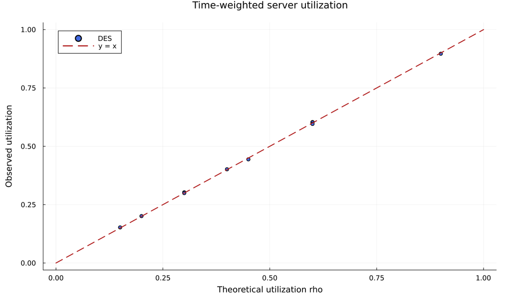

Загрузка близка к ρ.

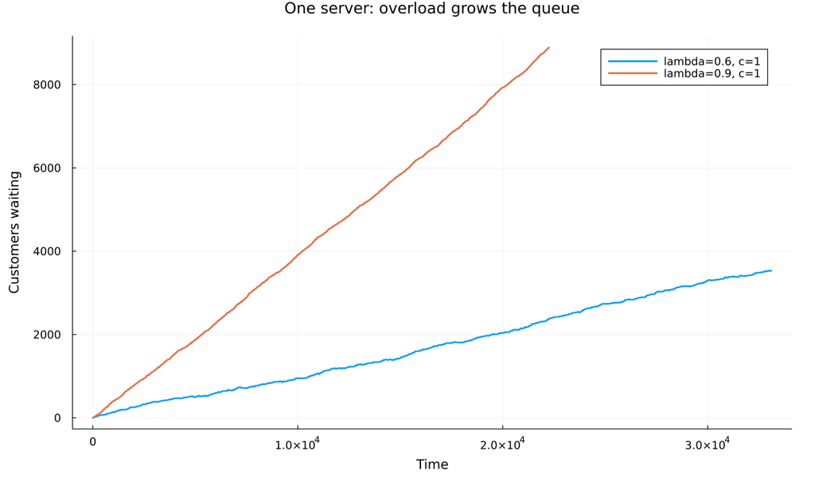

При λ>cμ очередь растёт.

При c=1, λ=0,6 и 0,9 теоретические стационарные значения не вычисляются.

# Система Росса

## Работающие машины, резерв и ремонт

- N=10 машин работают; S=3 находятся в холодном резерве.
- Средняя работа до отказа — 100 ч, ремонт — 1 ч.
- Отказавшую машину заменяет резервная; затем она ремонтируется.
- Исправленная машина возвращается в резерв.
- Авария: N−1 исправных машин, **не просто нулевой резерв**.

Один ремонтник — базовый случай; r=2 и r=3 — расширение модели.

## Аналитика поглощающей цепи

$$k=0,\ldots,S;\qquad a=N/F;\qquad b_k=\min(k,r)/G.$$

$$Qm=-\mathbf1,\qquad (-Q)^T v=e_0,\qquad E[T]=m_0=\sum_k v_k.$$

- k — число неисправных машин; S+1 — авария.
- E[T]=12 340 ч при N=10, S=3, r=1.
- Загрузка 0,09967585; средняя очередь 0,01053485.
- Для одного ремонтника результат проверен независимой рекуррентной формулой.

## Первый прогон: 12 715,718225 часа

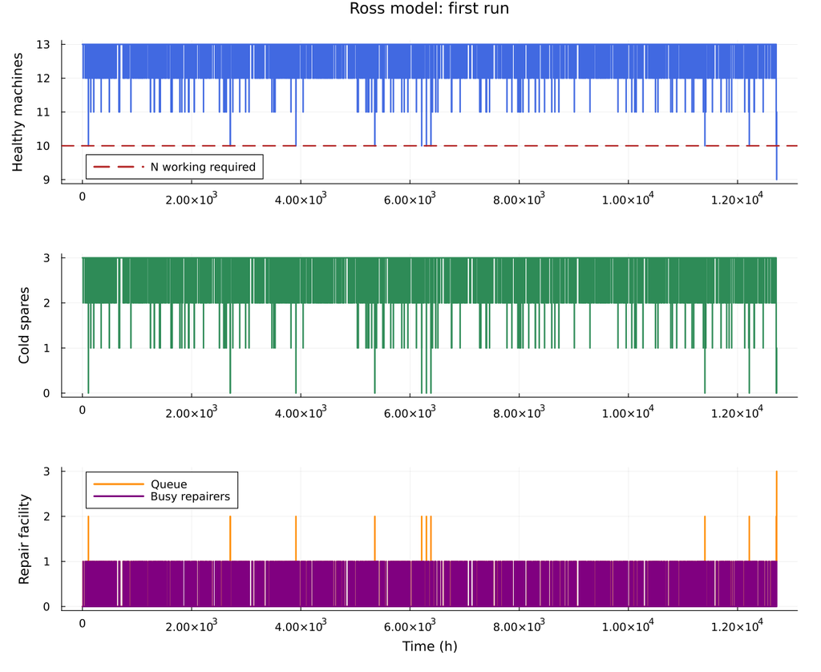

Исправные машины, холодный резерв, очередь и занятость ремонта.

## Авария после исчерпания резерва

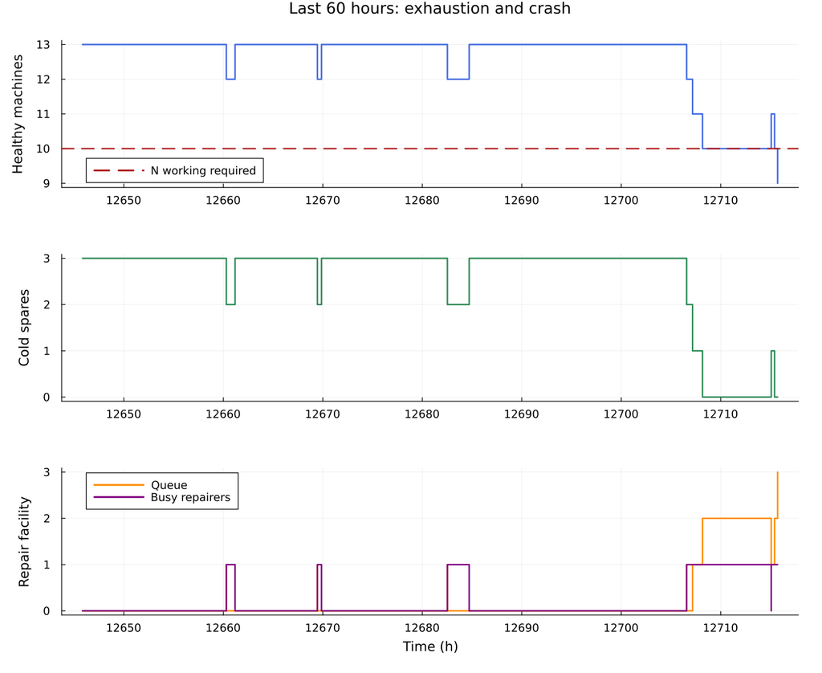

При 10 исправных система ещё работает; последний отказ оставляет 9.

## Пять наблюдений дают большой разброс

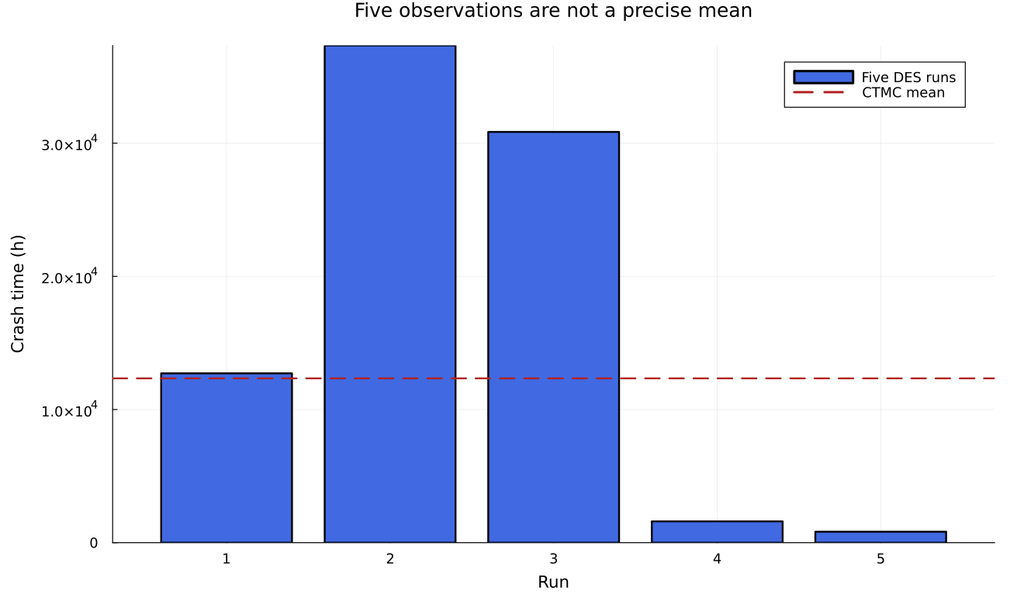

- Среднее: 16 664,247588 ч.
- Аналитика: 12 340 ч.
- SE: 7 489,259406 ч.
- Один поток StableRNG(42).

В исходнике объявлен SEED=150, но фактически применяется 42.

## Число машин и ремонтная мощность

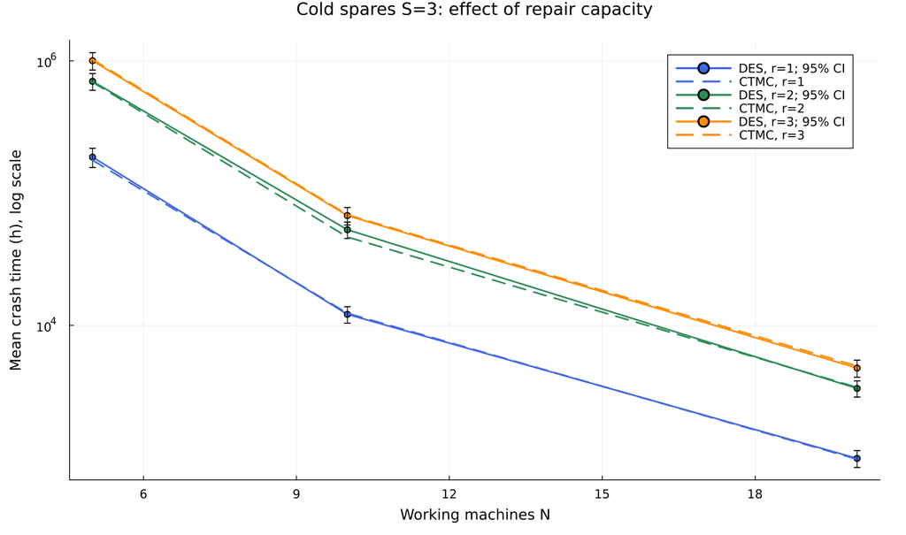

N={5;10;20}; r={1;2;3}; S=3. По 200 независимых прогонов — **1800 всего**.

Отрезки: приближённые 95%-е интервалы среднего. Ось времени логарифмическая.

## Очередь и загрузка считаются по времени

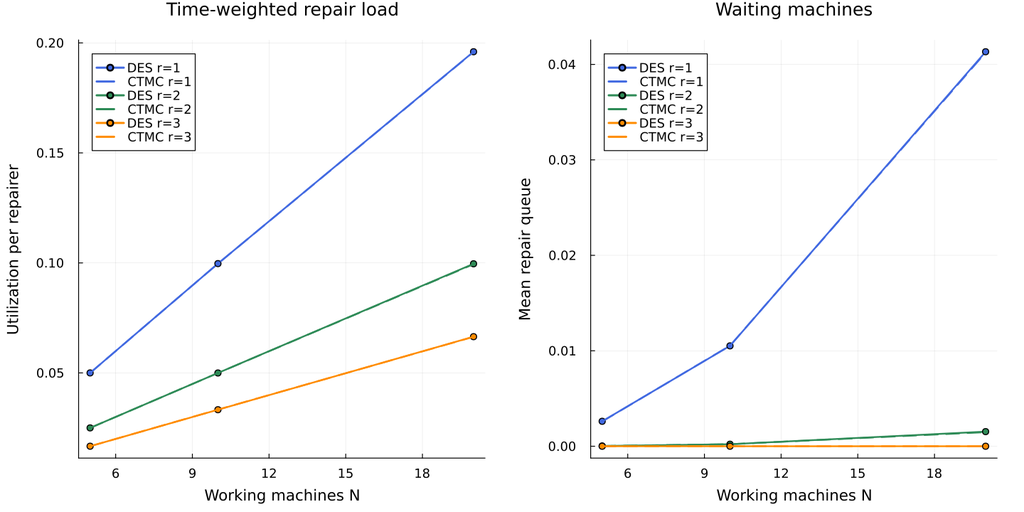

При r=S=3 до аварии очередь пуста, но авария всё ещё возможна.

Сравниваются Σarea_busy/(rΣT) и Σarea_queue/ΣT с аналитическими отношениями.

# Проверка результатов

## Четыре выполненных блокнота

[figure not shown]

Две модели × базовый и параметрический сценарии. Julia → Literate → JL/QMD/IPYNB.

Четыре QMD-фрагмента включены в тематические разделы отчёта.

## Командная последовательность

- `make tangle` — производные форматы четырёх сценариев;
- `make run` — базовые и параметрические вычисления;
- `make notebooks` — выполнение ячеек ядром Julia;
- `make docs` — HTML-документация;
- `make test` — 221 проверка.

CSV сохраняют фактические результаты, а не только итоговые рисунки.

## Что проверено и что ограничено

- FIFO, причинный порядок, ёмкость ресурса и интегралы состояний.
- Пять контрольных времён Росса, критерий аварии и сохранение машин.
- M/M/1, Эрланг C и независимая рекуррентная формула ремонта.
- 200 повторов не превращают приближённый интервал в точную гарантию.
- Экспоненциальные времена и холодный резерв — существенные предположения.

Источник задания: Королькова А. В., Кулябов Д. С., практикум, глава 7, с. 209–219.

## Выводы

- Очередь особенно чувствительна к загрузке вблизи единицы.
- Больше ремонтников — меньше накопление неисправностей и позже авария.
- При исходных условиях ремонт быстрый относительно общего потока отказов.
- Пять запусков Росса воспроизведены; выполнены все дополнительные исследования.
- Аналитика, CSV, графики и четыре блокнота согласованы с исходными моделями.